# Tutorial: Gráficos Contemporâneos e Animações

## Correlograma

Antes de explicarmos do que de fato se trata o correlograma, precisamos conhecer o que é uma matriz de correlação. Vejamos a seguir.

## O que é uma matriz de correlação?

A matriz de correlação é uma tabela que mostra o nível de correlação (Pearson, Spearman ou Kendall) entre variáveis quantitativas e ordinais. Veja o exemplo a seguir, baseado no dataset `Auto`, que contém algumas variáveis a respeito de 392 veículos.

Tabela 1: Correlação linear de Pearson entre variáveis do dataset Auto

|  | mpg | displacement | horsepower |
| --- | --- | --- | --- |
| mpg | 1.0000000 | -0.8051269 | -0.7784268 |
| displacement | -0.8051269 | 1.0000000 | 0.8972570 |
| horsepower | -0.7784268 | 0.8972570 | 1.0000000 |

Esse tipo de representação pode ser muito útil, mas com o aumento do número de variáveis envolvidas surge a dificuldade em identificar as correlações mais relevantes. Para simplificar essa análise, temos como uma alternativa o correlograma.

## O que é o correlograma?

O correlograma facilita a visualização de uma matriz de correlação e ainda permite explorar alguns outros aspectos dos dados, incorporando gráficos e cores, além das medidas de correlação em si.

Conforme observado na Tabela 1, a correlação entre $X$ e $Y$ é a mesma que entre $Y$ e $X$, logo, a matriz de correlação é simétrica em torno da diagonal principal. Por esta razão, podemos utilizar uma das metades para visualizar gráficos e a outra metade para obter as correlações, ou ainda utilizar uma medida de correlação para cada, por exemplo.

Além disso, como a correlação entre uma variável e ela mesma é sempre unitária. Podemos então descartar essa informação desinteressante e aproveitar a diagonal principal para exibir gráficos acerca da distribuição das variáveis, por exemplo.

Um dos pacotes encontrados mais completos em termos de elaboração desse tipo de gráfico, e que permite explorar essas propriedades descritas acima, é o pacote `GGally`.

## Correlograma com o pacote GGally

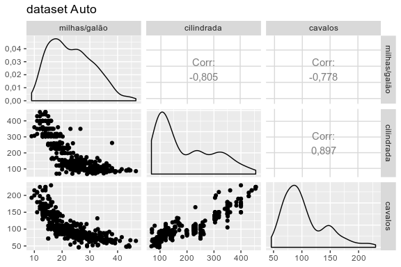

O código que cria o gráfico ‘básico’ é relativamente simples:

```r
library(GGally)

ggpairs(data = auto_dataset,
        columns = c("mpg", "displacement", "horsepower"),
        columnLabels = c("milhas/galão",
                         "cilindrada",
                         "cavalos"),
        title = "dataset Auto")
```

**`data`**: data frame contendo os dados;

**`columns`**: indica quais variáveis serão selecionadas para o gráfico;

**`columnLabels`**: rótulos para as respectivas variáveis;

**`title`**: título do gráfico.

**Obs:** Com este pacote é ainda possível escolher os tipos de gráficos mostrados no correlograma (densidade/histograma/barras) de acordo com o tipo de variável (contínua/discreta), além das medidas de correlação, tanto para a parte acima quanto abaixo da diagonal principal e também da própria diagonal.

Os parâmetros `upper` e `lower` te permitem alterar o que aparece nas metades superior e inferior, respectivamente. A estrutura básica para esses parâmetros é uma lista do tipo:

> `upper, lower = list(continous= * , discrete= * , combo= * )`

Os subparâmetros `continuous`, `discrete`, `combo` servem para definir a visualização das variáveis contínuas, discretas e ambas, respectivamente.

Para o subparâmetro `continuous` você pode atribuir um dos seguintes valores:

- `"points"`, se quiser ver gráficos de dispersão;
- `"smooth"`, para a dispersão acompanhada de uma reta;
- `"smooth_loess"`, para a dispersão acompanhada de uma curva alisada;
- `"density"`, para a distribuição de densidade;
- `"cor"`, para simplesmente obter a medida de correlação;
- `"blank"`, para nada mostrar.

Se quiser ainda especificar qual medida de correlação usar, pode trocar `"cor"` por `wrap("cor", method = "spearman"))`, para usar a medida de Spearman, por exemplo.

Já para o subparâmetro `discrete`:

- “`facetbar`”, para um gráfico de barras;
- “`blank`”, para nada mostrar.

Você ainda pode fazer algo parecido para escolher os gráficos que aparecem na diagonal principal, modificando o parâmetro `diag`. A sua estrutura é a mesma de `upper` e `lower`, exceto que que não recebe o subparâmetro `combo`.

Dentre gráficos de variáveis contínuas da diagonal, você pode escolher: `"densityDiag"`, `"barDiag"` e `"blankDiag"`. Já para variáveis discretas: `"barDiag"`, `"blankDiag"`.

> Como é possível perceber abaixo, é possível ainda passar parâmetros de estética do ggplot para o ggpairs.

Veja o exemplo a seguir:

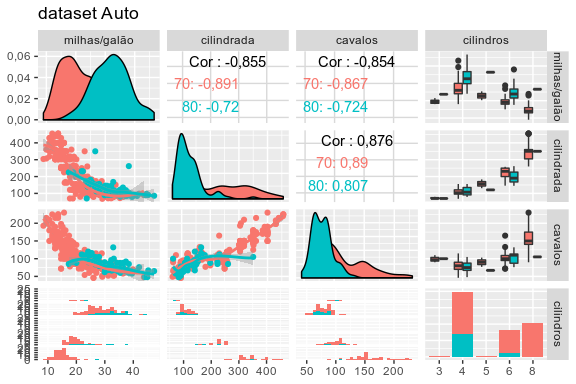

```r
# Definimos a variável cyl como discreta
auto_dataset$cylinders <- as.factor(auto_dataset$cylinders)

auto_dataset %>%
  # Definição da variável indicadora da década do veículo
  mutate(decade = as.factor(10*(year %/% 10)) ) %>%
  ggpairs(data = .,
          columns = c("mpg", "displacement", "horsepower", "cylinders"),
          columnLabels = c("milhas/galão",
                           "cilindrada",
                           "cavalos",
                           "cilindros"),
          title = "dataset Auto",
          # Destacar a cor de acordo com a década do veículo
          mapping = aes(color = decade),
          # Trocamos a medida de correlação das variáveis contínuas exibidas acima da
          # diagonal superior pela medida de Spearman
          upper = list(continuous = wrap("cor", method = "spearman")),
          # Escolhemos o gráfico de dispersão com a curva alisada para as variáveis
          # contínuas da parte inferior
          lower = list(continuous = "smooth_loess",
          # Já na diagonal, veremos gráficos de barras para as variáveis discretas
          diag = list(discrete="barDiag"))
  )
```

> Há uma série de outros parâmetros configuráveis, mas acredito que selecionei os principais dentre eles. Você pode encontrar mais em: [GGally - Extension to ‘ggplot2](https://ggobi.github.io/ggally/rd.html#ggpairs’)

Em seguida veremos uma outra forma de correlograma, feito pelo mesmo pacote. Este permite explorar um número muito maior de variáveis, resumindo a matriz de correlação em uma grade multicolorida.

## Um outro correlograma com o pacote GGally

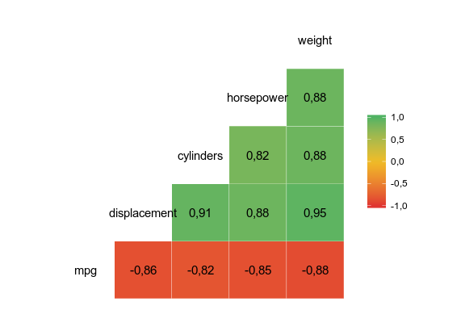

A criação desse gráfico acima é ainda mais simples do que o anterior. Vejamos:

```r
library(GGally)
library(dplyr)

auto_dataset %>%
  select(mpg, displacement, cylinders, horsepower, weight) %>%
  na.omit() %>%
  ggcorr(data = ., method = c("everything", "spearman"),
         label=TRUE, label_round=2,
         low="#e03531", mid="#f0bd27", high="#51b364")
```

> **Observação:** A escolha das variáveis que irão aparecer no gráfico deve ser feita previamente. Como é possível ver no código acima, usei a função `select()` do pacote `dplyr` para fazer isso.

**`data`**: data frame contendo os dados;

**`method`**: vetor contendo o tipo de tratamento aos dados faltantes (“everything”, “all.obs”, “complete.obs”, “na.or.complete”, “pairwise.complete.obs”) e a medida de correlação que será usada (“pearson”, “spearman”, “kendall”);

**`label`**: ativa/desativa o aparecimento do valor das correlações;

**`label_round`**: número de casas decimais mostradas no *label*;

**`low`**, **`mid`**, **`high`**: cores inferior, intermediária e superior da escala de cores, respectivamente.

## Precauções ao elaborar um correlograma

Note que este tipo de gráfico só se aplica a variáveis quantitativas ou ordinais, então você deve selecionar apenas esses tipos de variáveis ao criar o correlograma.

Outro cuidado a se tomar é escolher as medidas de correlação adequadas ao seu objetivo e ao tipo das variáveis.

- Se a sua intenção é apenas investigar se há uma relação de crescência/decrescência entre variáveis — não necessariamente linear —, você pode optar por usar a correlação de Spearman ou a de Kendall.
- Se a presença de *outliers* estiver afetando a análise, priorize o uso de uma das duas medidas robustas acima;
- Caso deseje analisar uma possível lineariedade entre variáveis quantitativas, você deverá usar a medida de correlação linear de Pearson.

> Diferente da medida de Pearson, as medidas de Spearman e de Kendall também se aplicam a variáveis ordinais, que não apresentam magnitude, mas apenas uma relação de ordem; como por exemplo classificações na escala de péssimo, ruim, regular, bom e excelente. Além disso, tais medidas também são robustas na presença de *outliers* (ou valores discrepantes).

Também é importantíssimo realizar o tratamento de dados faltantes antes de calcular as medidas de correlação. Você pode:

- Simplesmente remover as observações em pares que contêm NAs;
- Substituir os valores faltantes pela média ou mediana do restante dos valores.

Recomenda-se ainda evitar o uso de rótulos ou nomes longos para as variáveis, uma vez que pode-se prejudicar a visualização das informações contidas no gráfico.

## Alguns dos usos do correlograma

- Encontrar relações entre variáveis a serem exploradas:

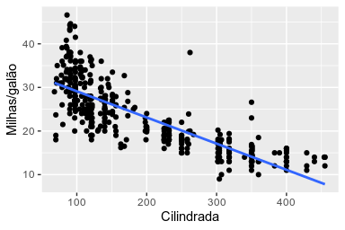

Graças ao correlograma mostrado anteriormente, encontramos a interessante relação descrita acima, que nos leva a:

- Estabelecer hipóteses e inferir sobre correlações:

$\mathbf{\hspace{3em} H_0}: \text{corr}(disp, mpg) = 0 \Leftrightarrow$ Não há correlação entre a cilindrada e a autonomia dos veículos

$\mathbf{\hspace{3em} H_1}: \text{corr}(disp, mpg) < 0 \Leftrightarrow$ Veículos de maior cilindrada apresentam menor automonia

Definimos então o nível de confiança do teste (5%), a métrica de correlação (Spearman) e prosseguimos com o teste:

```r
cor.test(auto_dataset$displacement, auto_dataset$mpg,
         alternative = "less", method = "spearman",
         conf.level=0.05)
```

```
##
##  Spearman's rank correlation rho
##
## data:  auto_dataset$displacement and auto_dataset$mpg
## S = 18625276, p-value < 2,2e-16
## alternative hypothesis: true rho is less than 0
## sample estimates:
##        rho
## -0,8552336
```

Dessa forma, sob a condição imposta por $\mathbf{H_0}$, o teste nos revela ser muito improvável (em relação a $\alpha$) observar na amostra uma correlação negativa entre essas variáveis tão ou mais expressiva quanto $-0,86$, conforme indicado pelo $\text{p-valor} < 2,2\cdot10^{-16}$.

Portanto, rejeitamos a hipótese nula em favor da hipótese alternativa de que a relação entre cilindrada e a autonomia dos veículos é negativa. Isso se traduz da seguinte forma: carros de maior cilindrada *tendem* a consumir mais combustível.

- Identificar possíveis relações causais

$\hspace{3em}$ **Ex:** dois carros idênticos exceto pelo número de cilindros consomem quantidades diferentes de combustível?

Essa parte, evidentemente, deve ser analisada com o maior cuidado possível, uma vez que para inferir causalidade devemos controlar todas as outras diferenças exceto as relativas às variáveis que estamos investigando.

> Neste caso específico, isso claramente não pode ser feito, posto que a alteração no número de cilindros acarreta uma série de outras diferenças no veículo.

Uma alternativa é realizar uma regressão de `mpg` (autonomia) sobre algumas outras variáveis como `cyl` (número de cilindros), `wt` (peso), `disp` (cilindrada) e etc, a fim de inferir a causalidade.